3.1 房价预测

总体介绍 主要是依据房屋的属性信息，包括房屋的卧室数量，卫生间数量，房屋的大小，房屋地下室的大小，房屋的外观，房屋的评分，房屋的修建时间，房屋的翻修时间，房屋的位置信息等，对房屋的价格进行预测，从而为此类价格类实际问题的处理提供技术参考。这本质上是一个回归问题。 本地离线数据集：kc_house_data.csv

一.导入实验环境

步骤 1 导入相应的模块 本实验使用到的框架主要包括numpy，pandas，scikit-learn，matplotlib，seaborn库。

```python
import numpy as np
import pandas as pd
import matplotlib.pyplot as plt
import seaborn as sns
sns.set_style(style="darkgrid")
```

二.数据准备

步骤 1 离线数据读取

```python
df = pd.read_csv(r"D:\QQ下载\华为可选题目\华为可选题目\集成学习\房价预测\房价预测\kc_house_data.csv")
```

```python
print(df.sample(5))
```

```
               id             date     price  bedrooms  bathrooms  \
12473  5490210510  20140922T000000  500000.0         3       1.75
15990  4472000050  20150309T000000  265000.0         3       2.50
11746  3574900030  20150327T000000  585000.0         4       2.50
19413  7340600068  20140514T000000  215000.0         2       1.00
14664  8562901830  20140805T000000  454800.0         4       2.25

       sqft_living  sqft_lot  floors  waterfront  view  ...  grade  \
12473         1530     14633     1.0           0     0  ...      7
15990         1890      6088     2.0           0     0  ...      7
11746         2200      9099     2.0           0     0  ...      8
19413         1240      7200     1.0           0     0  ...      7
14664         2490     10720     1.0           0     1  ...      7

       sqft_above  sqft_basement  yr_built  yr_renovated  zipcode      lat  \
12473        1100            430      1977             0    98052  47.6949
15990        1890              0      1996             0    98002  47.2886
11746        2200              0      1994             0    98034  47.7330
19413        1240              0      1967             0    98168  47.4971
14664        1400           1090      1979             0    98074  47.6137

          long  sqft_living15  sqft_lot15
12473 -122.119           1780        8100
15990 -122.218           1700        6600
11746 -122.225           2270        8900
19413 -122.282           1130        9200
14664 -122.060           3080       10720

[5 rows x 21 columns]
```

三. 数据理解

步骤 1 输出属性信息

```python
print(df.info())
```

```
<class 'pandas.core.frame.DataFrame'>
RangeIndex: 21613 entries, 0 to 21612
Data columns (total 21 columns):
 #   Column         Non-Null Count  Dtype
---  ------         --------------  -----
 0   id             21613 non-null  int64
 1   date           21613 non-null  object
 2   price          21613 non-null  float64
 3   bedrooms       21613 non-null  int64
 4   bathrooms      21613 non-null  float64
 5   sqft_living    21613 non-null  int64
 6   sqft_lot       21613 non-null  int64
 7   floors         21613 non-null  float64
 8   waterfront     21613 non-null  int64
 9   view           21613 non-null  int64
 10  condition      21613 non-null  int64
 11  grade          21613 non-null  int64
 12  sqft_above     21613 non-null  int64
 13  sqft_basement  21613 non-null  int64
 14  yr_built       21613 non-null  int64
 15  yr_renovated   21613 non-null  int64
 16  zipcode        21613 non-null  int64
 17  lat            21613 non-null  float64
 18  long           21613 non-null  float64
 19  sqft_living15  21613 non-null  int64
 20  sqft_lot15     21613 non-null  int64
dtypes: float64(5), int64(15), object(1)
memory usage: 3.5+ MB
None
```

步骤 2 输出描述信息

```python
print(df.describe())
```

```
                 id         price      bedrooms     bathrooms   sqft_living  \
count  2.161300e+04  2.161300e+04  21613.000000  21613.000000  21613.000000
mean   4.580302e+09  5.400881e+05      3.370842      2.114757   2079.899736
std    2.876566e+09  3.671272e+05      0.930062      0.770163    918.440897
min    1.000102e+06  7.500000e+04      0.000000      0.000000    290.000000
25%    2.123049e+09  3.219500e+05      3.000000      1.750000   1427.000000
50%    3.904930e+09  4.500000e+05      3.000000      2.250000   1910.000000
75%    7.308900e+09  6.450000e+05      4.000000      2.500000   2550.000000
max    9.900000e+09  7.700000e+06     33.000000      8.000000  13540.000000

           sqft_lot        floors    waterfront          view     condition  \
count  2.161300e+04  21613.000000  21613.000000  21613.000000  21613.000000
mean   1.510697e+04      1.494309      0.007542      0.234303      3.409430
std    4.142051e+04      0.539989      0.086517      0.766318      0.650743
min    5.200000e+02      1.000000      0.000000      0.000000      1.000000
25%    5.040000e+03      1.000000      0.000000      0.000000      3.000000
50%    7.618000e+03      1.500000      0.000000      0.000000      3.000000
75%    1.068800e+04      2.000000      0.000000      0.000000      4.000000
max    1.651359e+06      3.500000      1.000000      4.000000      5.000000

              grade    sqft_above  sqft_basement      yr_built  yr_renovated  \
count  21613.000000  21613.000000   21613.000000  21613.000000  21613.000000
mean       7.656873   1788.390691     291.509045   1971.005136     84.402258
std        1.175459    828.090978     442.575043     29.373411    401.679240
min        1.000000    290.000000       0.000000   1900.000000      0.000000
25%        7.000000   1190.000000       0.000000   1951.000000      0.000000
50%        7.000000   1560.000000       0.000000   1975.000000      0.000000
75%        8.000000   2210.000000     560.000000   1997.000000      0.000000
max       13.000000   9410.000000    4820.000000   2015.000000   2015.000000

            zipcode           lat          long  sqft_living15     sqft_lot15
count  21613.000000  21613.000000  21613.000000   21613.000000   21613.000000
mean   98077.939805     47.560053   -122.213896    1986.552492   12768.455652
std       53.505026      0.138564      0.140828     685.391304   27304.179631
min    98001.000000     47.155900   -122.519000     399.000000     651.000000
25%    98033.000000     47.471000   -122.328000    1490.000000    5100.000000
50%    98065.000000     47.571800   -122.230000    1840.000000    7620.000000
75%    98118.000000     47.678000   -122.125000    2360.000000   10083.000000
max    98199.000000     47.777600   -121.315000    6210.000000  871200.000000
```

步骤 3 输出空值信息

```python
print(df.isnull().any())
```

```
id               False
date             False
price            False
bedrooms         False
bathrooms        False
sqft_living      False
sqft_lot         False
floors           False
waterfront       False
view             False
condition        False
grade            False
sqft_above       False
sqft_basement    False
yr_built         False
yr_renovated     False
zipcode          False
lat              False
long             False
sqft_living15    False
sqft_lot15       False
dtype: bool
```

步骤 4 查看每种属性与房价的分布关系

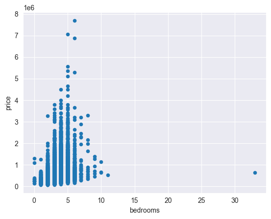

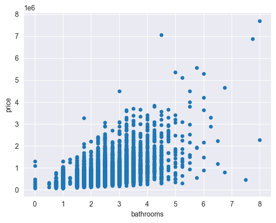

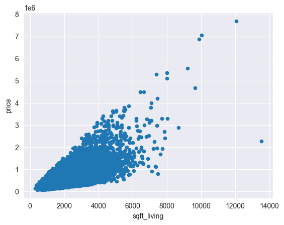

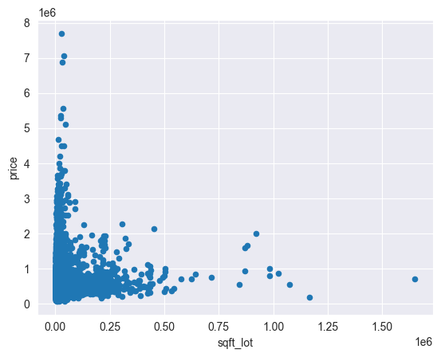

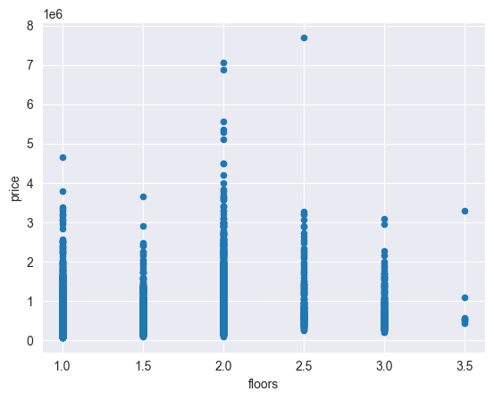

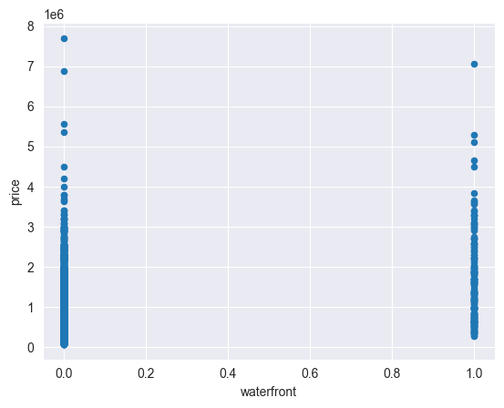

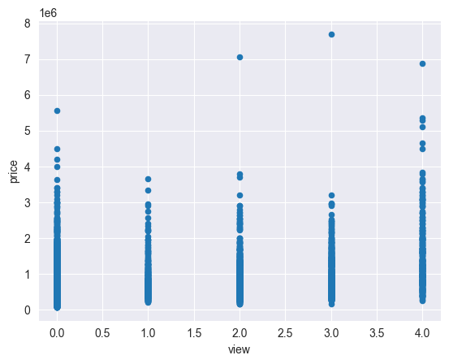

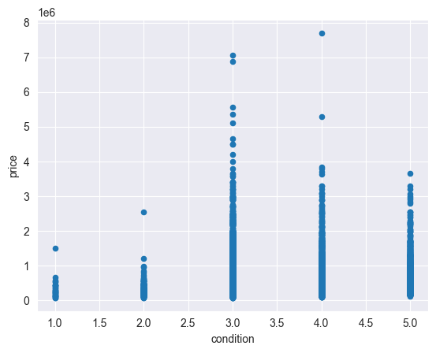

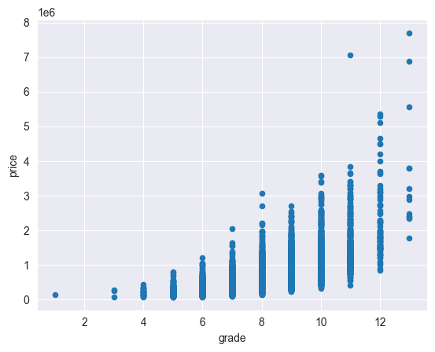

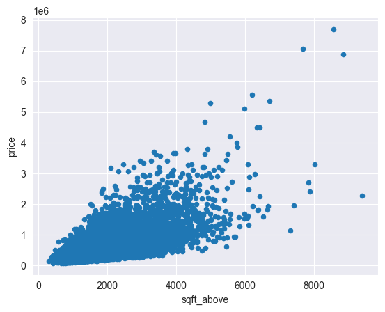

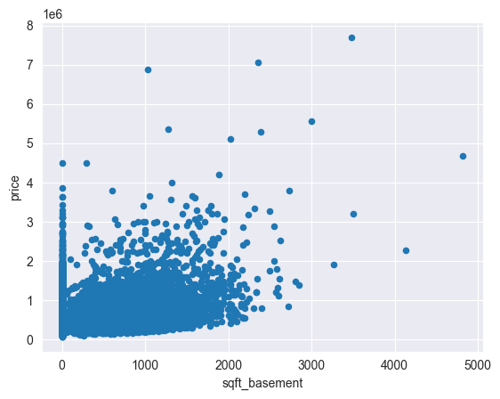

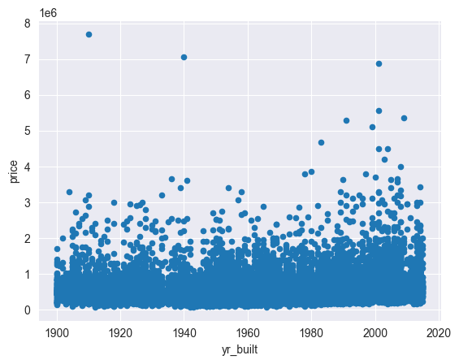

[6 more figures not shown]

```python
x_vars=df.columns[3:]
for x_var in x_vars:
    df.plot(kind='scatter', x=x_var, y='price')
```

步骤 5 查看属性之间的相关性

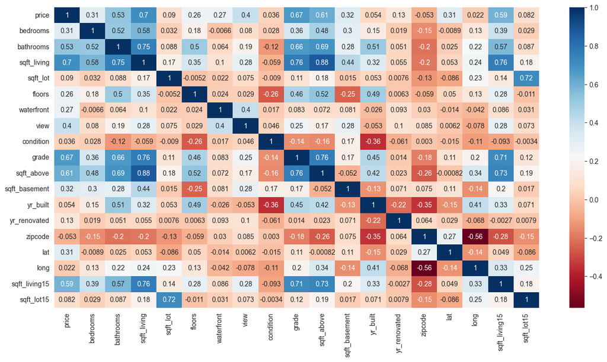

```python
df.drop(["id"],axis=1,inplace=True)
corr = df.corr(numeric_only=True)
plt.figure(figsize=(16,8))
sns.heatmap(corr,annot=True,cmap="RdBu")
plt.show()
```

步骤 6 显示下三角的相关系数，用于呈现属性之间的相关系数图，简化相关系数图。 由于相关系数热力图矩阵是对称的，因此只需呈现一部分即可分析属性间的关系。

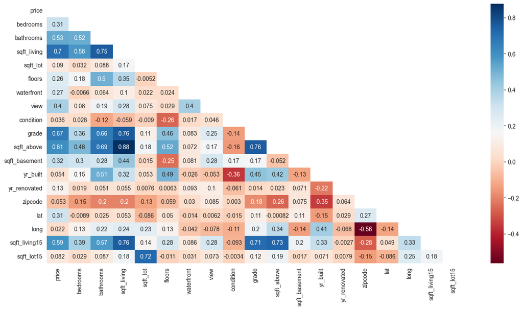

```python
plt.figure(figsize=(16,8))
mask = np.zeros_like(corr,dtype=bool)
# Create a msk to draw only lower diagonal corr map
mask[np.triu_indices_from(mask)] = True
sns.set_style(style="white")
sns.heatmap(corr,annot=True,cmap="RdBu",mask=mask)
plt.show ()
```

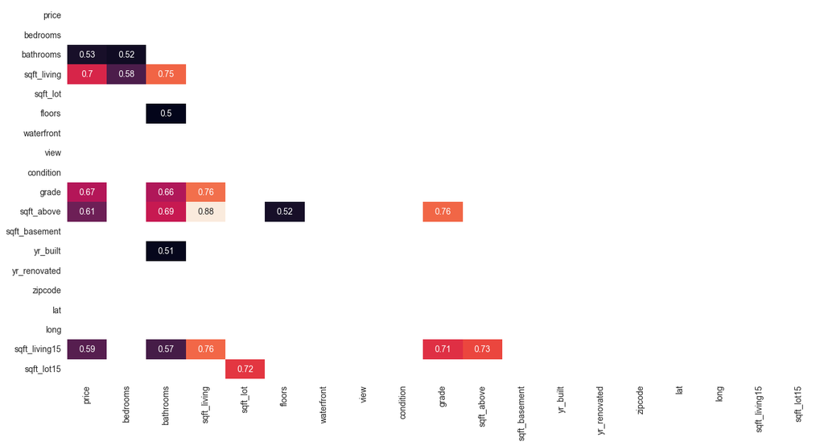

```python
plt.figure(figsize=(16,8))
mask = np.zeros_like(corr[corr>=.5],dtype=bool)

# Create a msk to draw only lower diagonal corr map
mask[np.triu_indices_from(mask)] = True
sns.set_style(style="white")
sns.heatmap(corr[corr>=.5],annot=True,mask=mask,cbar=False)
plt.show()
```

步骤 7 查看所有房子的地理分布的散点图，查看房屋的地理分布是否存在相关的分布规律

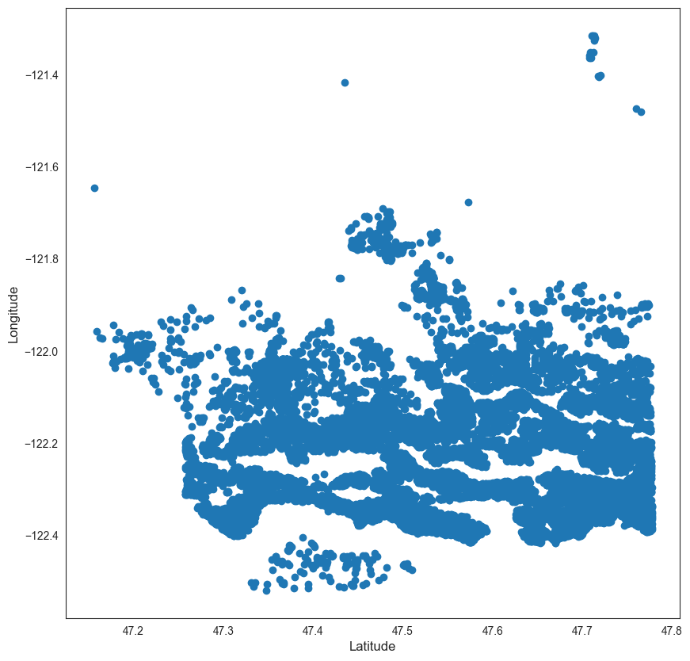

```python
plt.figure(figsize=(10,10))
#调用散点图模块，依据经纬度绘制散点图
plt.scatter(df.lat, df.long)
plt.ylabel('Longitude', fontsize=12)
plt.xlabel('Latitude', fontsize=12)
plt.show()
```

步骤 8 分析邮编与房价的分布关系

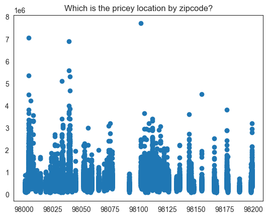

```python
plt.scatter(df.zipcode,df.price)
plt.title("Which is the pricey location by zipcode?")
plt.show()
```

四.模型训练数据处理